# Analysing the PISA 2012 datset

## by Gad Mohamed

## Investigation Overview

In this investigation, I am going to answer the following questions:

1. Do parents' educational background influence students' grades ?
2. How studying time affects students' grades ?

## Dataset Overview

> In this investigation, I am using PISA2012 dataset. PISA is an education assessment dataset based on survey's on students, parents and teachers. The dataset is huge, but in this analysis, I do a lot of cleaning to focus only on the features relevant to the questions of interest.

> The original PISA2012 dataset contains 485490 records and 636 features. After removing irrelevant features and merging parents' qualifications, study time, and subjects' scores, the clean dataset has 129199 records and 9 features.

## (Parents' qualifications vs students' grades)

> Although students' scores were increasing linearly with parents' qualifications, scores start to decrease at very high qualifications. May be this is a signal that highly qualified parents are busy caring about their children

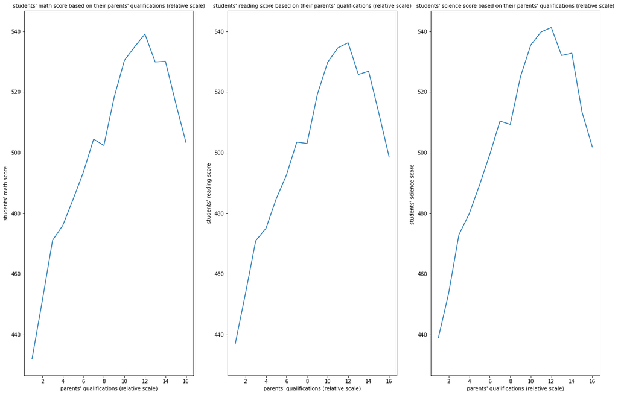

## (Fathers' vs Mothers' educational qualifications)

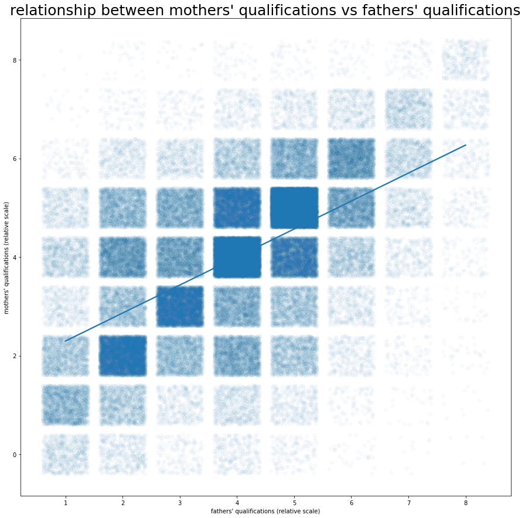

## (Students' grades relation with parents' qualifications and studying time)

> The following heat map shows two clusters of blocks, in the upper left and in the lower right. The first cluster (in the upper left) shows high correlation among students' scores i.e. students tend to get similar results in most of their subjects. The second cluster (in the lower right) shows high correlation between fathers' and mothers' qualifications. However, the other two sides, upper right and lower left shows low correlation. Surprisingly, average study time of students didn't have much influence (correlation) on their grades.

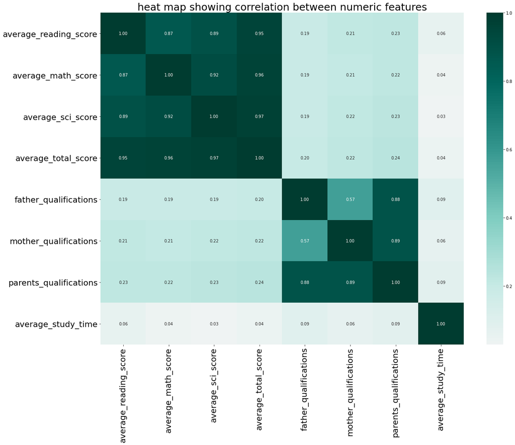